# Final Project

Kevin Collins

4/27/2020

### Foreword

The goal of this project is to attempt to predict federal income tax bracket for college degree holders in New York City as a function of field of degree, race, sex, and age.

We will be using IPUMS microdata from the 2018 5-Year ACS to construct various statistical learning models in order to hopefully uncover how best to answer this question.

There were many iterations of this project, wherein I struggled to deal with data size and dimensions. These are not the most efficient models, but I think we will see that it is quite a difficult problem. Obviously, having more predictor variables is always an asset, but the progress we make through these models is enlightening to the kinds of techniques that might better work for a question of this sort without using intensive computing resources.

### Data Cleaning

```r
ipums.data <- fread("usa_00002.csv")
deg.labels <- fread("deg_label.csv")[,c(1,2)]
colnames(deg.labels) <- c("DEGFIELD", "deg.field")
deg.labels$DEGFIELD <- as.factor(deg.labels$DEGFIELD)
race.labels <- fread("race_label.csv")[,c(1,2)]
colnames(race.labels) <- c("RACE", "race")
race.labels$RACE <- as.factor(race.labels$RACE)
```

The following cleaning steps were taken:

-Filtering for only New York, NY.

-Filtering out those who do not hold college degrees.

-Converting numeric codes to actual labels for race and field of degree variables.

-Adding a variable ‘federal.tax’ that describes the 2019 federal tax bracket based on income.

```r
ipums <- ipums.data  %>% filter(CITY == 4610)

ipums$DEGFIELD <- as.factor(ipums$DEGFIELD)
ipums$RACE <- as.factor(ipums$RACE)

ipums <- ipums %>%
  left_join(deg.labels,
            by = "DEGFIELD") %>%
  left_join(race.labels,
            by = "RACE")

ipums <- ipums %>%
  filter(DEGFIELD != 0) %>%
  select(SEX, AGE, race, deg.field, INCTOT)

ipums$deg.field <- as.factor(ipums$deg.field)

ipums <- data.frame(ipums)

#2019 federal tax rates
ipums <- ipums%>%
  mutate(federal.tax = cut(ipums$INCTOT, breaks = c(min(ipums$INCTOT)-1, 9700, 39475, 84200, 160725, 204100, 510300, max(ipums$INCTOT)+1)))

levels(ipums$federal.tax) <- c("10%", "12%", "22%", "24%", "32%", "35%", "37%")
```

As previously referenced, the dimensions of this problem became quite difficult, so I attempted to combine some levels within the field of degree and race variables that I felt were similar enough to be justified.

```r
degrees <- c("Professional Degree", "Other", "Social Sciences", "Physical Sciences",  "Business",
             "Communications", "Communications", "Computer Sciences", "Other",
             "Other", "Other", "Professional Degree", "Tech",  "Engineering", "Engineering",  "Humanities", "Physical Sciences", "Other", "Fine Arts", "Other", "Humanities", "Professional Degree", "Humanities", "Other", "Humanities", "Linguistics and Foreign Languages", "Mathematics and Statistics", "Medical and Health Sciences and Services",  "Tech", "Tech",  "Humanities",  "Other",  "Physical Sciences", "Social Sciences", "Other", "Social Sciences",  "Humanities", "Tech")

levels(ipums$deg.field) <- degrees

ipums$race <-  factor(ipums$race)
levels(ipums$race)[c(6,7,8)] <- "Other race"
```

We will create a 70/30 test-training split.

```r
indexes <- sample(nrow(ipums),
                  size = .7*nrow(ipums),
                  replace = FALSE)
ipums.train <- ipums[indexes,]
ipums.test <- ipums[-indexes,]

write.csv(ipums.train,
          "ipums.train.csv")
write.csv(ipums.test,
          "ipums.test.csv")
```

Reading in our already cleaned and separated data to expedite the process of knitting the findal html file.

```r
ipums.train <- fread("ipums.train.csv")
ipums.test <- fread("ipums.test.csv")
ipums <- rbind(ipums.test, ipums.train)
```

### EDA

First, let’s take a look at the income distribution of our population subset.

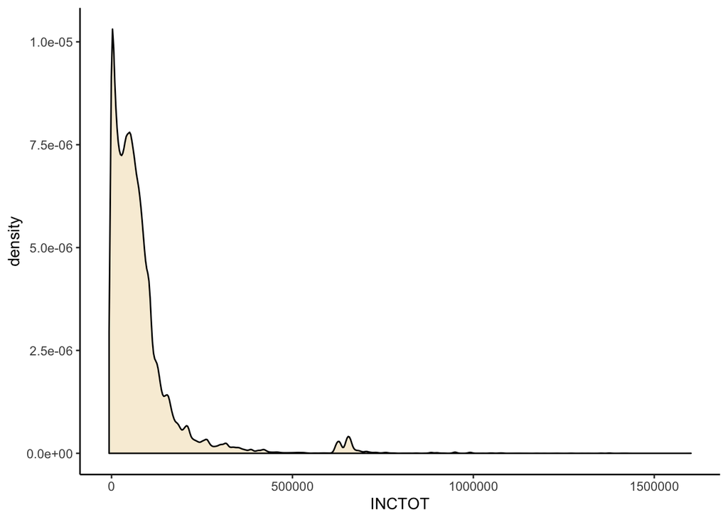

```r
ipums %>%
  ggplot(aes(x = INCTOT)) +
  geom_density(fill = "goldenrod",
               alpha = 0.2) +
  theme_classic()
```

```r
summary(ipums$INCTOT)
```

```
##    Min. 1st Qu.  Median    Mean 3rd Qu.    Max.
##   -6771   22641   55843   81824   95291 1601506
```

There is a massive right-skew going on here, which may prove difficult for prediction. Let’s take a look at the actual breakout of federal tax brackets.

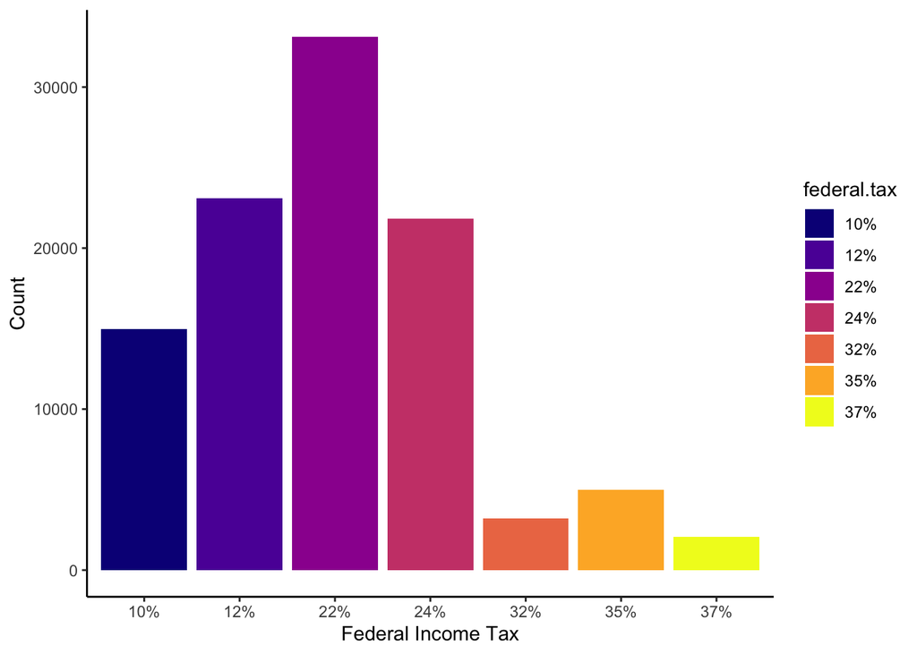

```r
ipums %>%
  ggplot(aes(x = federal.tax)) +
  geom_bar(aes(fill = federal.tax)) +
  theme_classic() +
  xlab("Federal Income Tax") +
  ylab("Count") +
  scale_fill_viridis_d(option = "C")
```

Similarly to the previous graph, we see a right-skewed distribution. The 22% bracket is the most populous, while 32%, 35%, and 37% are drastically less populated than the lower four. This will prove difficult to classify, given their underrepresentation, but hopefully there are some measures that can be taken.

Moving onto breakouts of each of our variables:

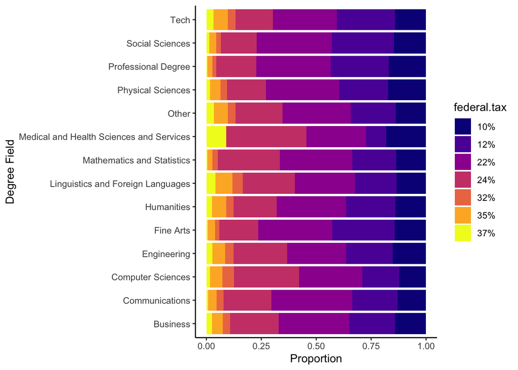

```r
ipums %>%
  ggplot(aes(x = deg.field)) +
  geom_bar(aes(fill  = federal.tax),
           position = "fill") +
  coord_flip() +
  theme_classic() +
  scale_fill_viridis_d(option = "C") +
  xlab('Degree Field') +
  ylab('Proportion')
```

There are fairly expected variations here- notably, medical services, engineering, and computer sciences seem to end up in higher tax brackets. Something that I found surprising is the distribution for Linguistics and Foreign Languages. Perhaps there is a lot of money to be made for a translator.

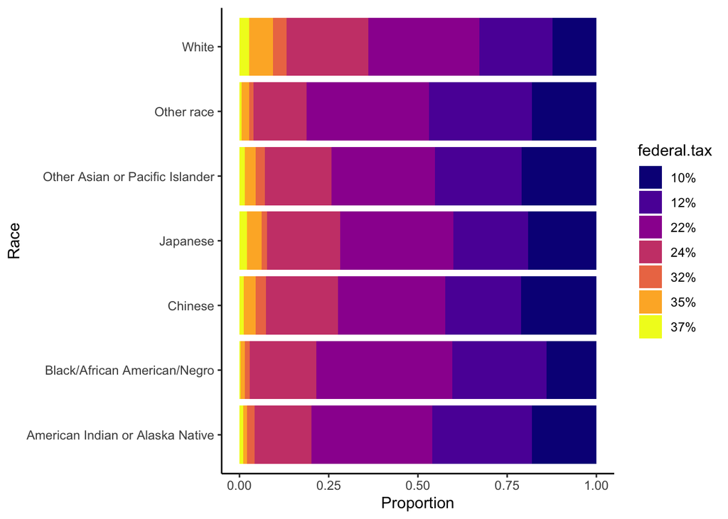

```r
ipums %>%
  ggplot(aes(x = race)) +
  geom_bar(aes(fill  = federal.tax),
           position = "fill") +
  coord_flip() +
  theme_classic() +
  scale_fill_viridis_d(option = "C") +
  xlab('Race') +
  ylab('Proportion')
```

There are essentially three distribution tiers going on here: We see white people are typically populating the higher tax brackets, followed by Asian populations, and then black people, indigenous people, and those of mixed races are typically lower/middle income.

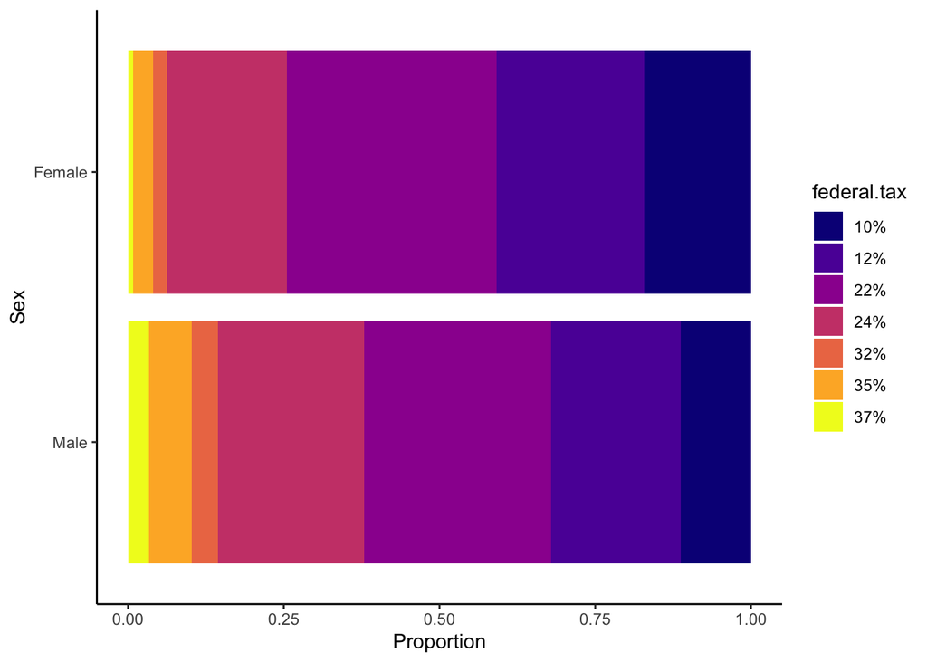

```r
ipums %>%
  ggplot(aes(x = factor(SEX))) +
  geom_bar(aes(fill  = federal.tax),
           position = "fill") +
  coord_flip() +
  theme_classic() +
  scale_fill_viridis_d(option = "C") +
  xlab('Sex') +
  ylab('Proportion') +
  scale_x_discrete(labels = c('Male', 'Female'))
```

A higher proportion of men inhabit the upper tax brackets than women.

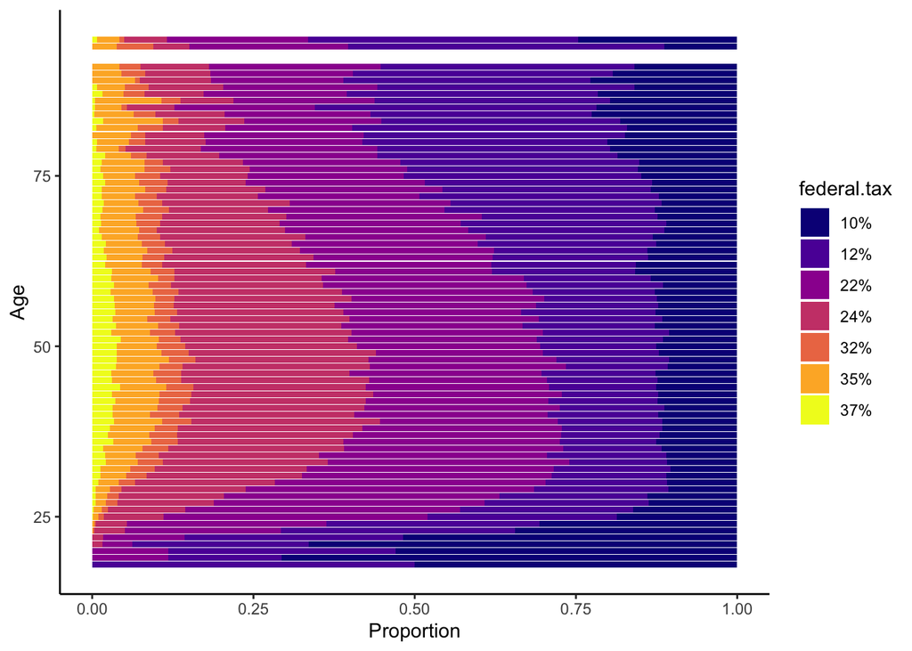

```r
ipums %>%
  ggplot(aes(x = AGE)) +
  geom_bar(aes(fill  = federal.tax),
           position = "fill") +
  coord_flip() +
  theme_classic() +
  scale_fill_viridis_d(option = "C") +
  xlab('Age') +
  ylab('Proportion')
```

The age breakout is particularly interesting. Naturally, people make more money as they get older, but they seem to peak around age 50. What accounts for this decrease? Instinct says that the wealthy begin to retire and then therefore have less annual income. Notably, the proportion of the population in the bottom bracket becomes fairly steady after about age 25, which implies little mobility in or out of that bracket.

What do all of these variables have in common?

### Unsupervised Learning

We will utilize k-means clustering to see if we can emulate the categorization of tax brackets by using only race, sex, age, and field of degree.

First, however, we need to create dummy variables for each of our factor-based variables.

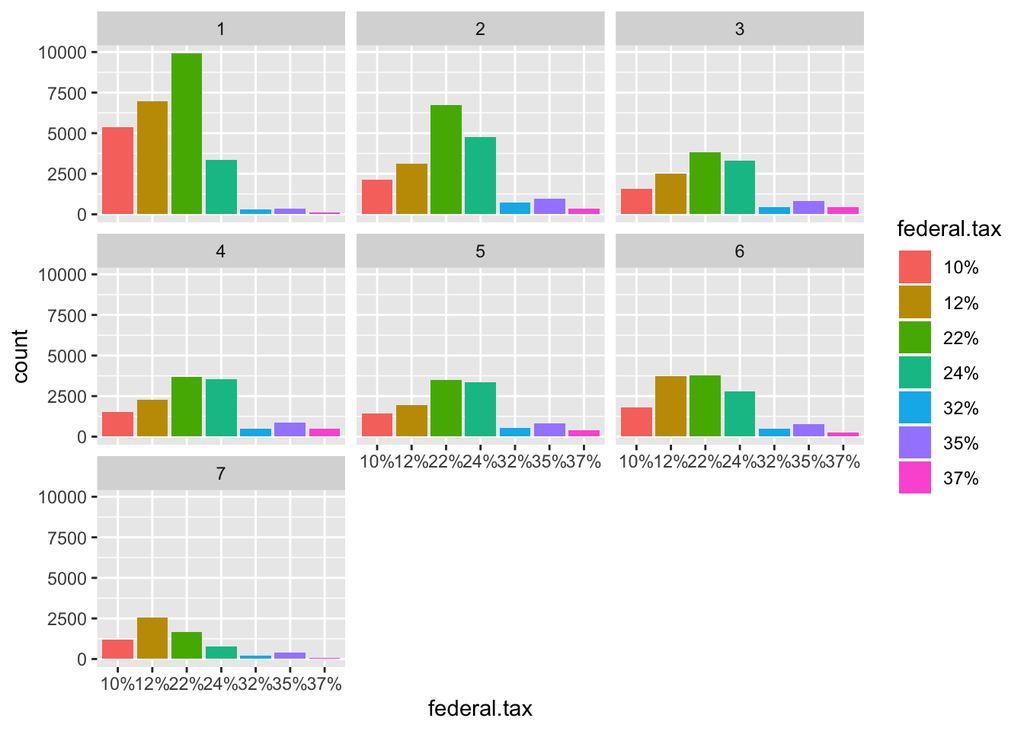

```r
ipums.train_dummy <- dummy_cols(ipums.train, select_columns = c("race", "deg.field")) %>%
  select(-INCTOT, -race, -deg.field, -federal.tax, -SEX, -V1)
ipums.test_dummy <- dummy_cols(ipums.test, select_columns = c("race", "deg.field")) %>%
  select(-INCTOT, -race, -deg.field, -federal.tax, -SEX, -V1)

ipums_dummy <- rbind(ipums.test_dummy,
                     ipums.train_dummy)

km <- kmeans(ipums_dummy,
             7)

clusters <- factor(km$cluster)

cluster.data <- data.frame(clusters,
           federal.tax = ipums$federal.tax)

cluster.data %>%
  ggplot(aes(x = federal.tax)) +
  geom_bar(aes(fill = federal.tax)) +
  facet_wrap(~clusters)
```

Let’s move into the modeling portion of this exercise.

### Metrics of Evalution

First, we need to define how we will compare our models against on another. In order to be somewhat exhaustive, we will consider the three following metrics.

##### Accuracy

Perhaps the most basic metric, how accurate is the model? How many observations does it correctly classify? This is important to consider because at the end of the day we want our model to do its job correctly. However, since we are dealing with a multiclass problem, this doesn’t necessarily paint the whole picture.

##### Cohen’s Kappa

Using Kappa, we will be able to tell whether we are performing better than simple random guessing. At the very least, we hope to be able to construct a model that is more powerful than a random guess. This is also necessary to contrast with accuracy. Since we have such unbalanced classes, it might yield decent accuracy to simply throw a bunch of guesses into the most populous brackets, but that’s still somewhat random guessing. Can we do better than that?

##### Precision/Recall

Finally, we will also use precision and recall to judge class-specific performance. I foresee that the higher tax brackets will be harder to predict, so precision and recall will help us understand how different models perform with respect to each individual class.

We will look at each of these three metrics to compare the following models. In order to do so, I’ve written a function that will output all three and a confusion matrix given a prediction vector and an answer vector.

```r
performance <- function(predicted, actual){
  confusion <- table(predicted, actual)
  print(confusion)

  performance <- data.frame(Accuracy = sum(diag(confusion))/sum(confusion),
                            Cohen.Kappa = cohen.kappa(confusion)$kappa)

  print(performance)

  precision.recall <- data.frame(recall = diag(confusion)/apply(confusion, 1, sum),
                                 precision = diag(confusion)/apply(confusion, 2, sum))
  print(precision.recall)

  performance.metrics <- list(confusion, performance, precision.recall)
}
```

### Supervised Learning

##### Linear Regression

First, we construct a simple linear model.

Now linear regression does not lend itself to classification, so we will do a point-estimate preidction on the INCTOT variable, and then classify the tax bracket based on that.

```r
linear.model  <- lm(INCTOT ~ AGE + SEX + race + deg.field,
                    data = ipums.train)

save(linear.model,
     file = 'linear.model.R')
```

```r
load('linear.model.R')

lm.predict <- data.frame(prediction  = predict(linear.model,
                                               ipums.test))

lm.predict <- lm.predict %>%
  mutate(predicted.bracket = cut(lm.predict$prediction, breaks = c(min(ipums$INCTOT)-1, 9700, 39475, 84200, 160725, 204100, 510300, max(ipums$INCTOT)+1)))

levels(lm.predict$predicted.bracket) <- c("10%", "12%", "22%", "24%", "32%", "35%", "37%")

performance(lm.predict$predicted.bracket, ipums.test$federal.tax)
```

```
##          actual
## predicted  10%  12%  22%  24%  32%  35%  37%
##       10%    0    0    0    0    0    0    0
##       12%  329  494  585  221   16   13    6
##       22% 2524 3436 5121 2757  312  391  107
##       24% 1649 2938 4324 3544  603 1126  499
##       32%    0    0    0    1    0    0    0
##       35%    0    0    0    0    0    0    0
##       37%    0    0    0    0    0    0    0
##    Accuracy Cohen.Kappa
## 1 0.2954897  0.04212473
##        recall  precision
## 10%       NaN 0.00000000
## 12% 0.2968750 0.07192778
## 22% 0.3496040 0.51056830
## 24% 0.2413676 0.54330829
## 32% 0.0000000 0.00000000
## 35%       NaN 0.00000000
## 37%       NaN 0.00000000
```

This model is not a great start. We achieve an accuracy of under 30% with a Kappa of .042, which implies that our linear model is barely doing better than random guessing. This should be fairly expected given the distribution of income, our model is highly unlikely to predict anyone has a high enough income to get in the three uppermost brackets. What’s interesting, is the same is reflected for the 10% bracket. Our model focuses all predictions on the three most populous income brackets. Precision/Recall are also not great for any of the categories.

Hopefully we can do better moving forward!

##### One vs. Rest - Logistic Regression

For our next model, we’ll try logistic regression. My logic for this approach is that in the past it has been useful for binary classification. However, I wish to extend this to multi-classification. Therefore, I will take a one vs. rest approach, wherein I will construct 7 different models, each of which will calculate the probability of being in each tax bracket vs not. Then, the highest probability will be the ensemble’s vote.

```r
logit.data <- dummy_cols(ipums.train, select_columns = "federal.tax")

logit.1 <- glm(`federal.tax_10%` ~ AGE + SEX + race + deg.field,
    data = logit.data,
    family = "binomial")
save(logit.1,
     file = "logit.1.R")

logit.2 <- glm(`federal.tax_12%` ~ AGE + SEX + race + deg.field,
    data = logit.data,
    family = "binomial")
save(logit.2,
     file = "logit.2.R")

logit.3 <- glm(`federal.tax_22%` ~ AGE + SEX + race + deg.field,
    data = logit.data,
    family = "binomial")
save(logit.3,
     file = "logit.3.R")

logit.4 <- glm(`federal.tax_24%` ~ AGE + SEX + race + deg.field,
    data = logit.data,
    family = "binomial")
save(logit.4,
     file = "logit.4.R")

logit.5 <- glm(`federal.tax_32%` ~ AGE + SEX + race + deg.field,
    data = logit.data,
    family = "binomial")
save(logit.5,
     file = "logit.5.R")

logit.6 <- glm(`federal.tax_35%` ~ AGE + SEX + race + deg.field,
    data = logit.data,
    family = "binomial")
save(logit.6,
     file = "logit.6.R")

logit.7 <-glm(`federal.tax_37%` ~ AGE + SEX + race + deg.field,
    data = logit.data,
    family = "binomial")
save(logit.7,
     file = "logit.7.R")
```

```r
load("logit.1.R")
load("logit.2.R")
load("logit.3.R")
load("logit.4.R")
load("logit.5.R")
load("logit.6.R")
load("logit.7.R")
```

```r
logit.prediction <- data.frame()

logit.prediction <- rbind(logit.prediction,
                          data.frame(obs = c(1:nrow(ipums.test)),
                                     prob = predict.glm(logit.1,
                                                        ipums.test,
                                                        type = "response"),
                                     federal.tax = rep("10%", nrow(ipums.test))))
logit.prediction <- rbind(logit.prediction,
                          data.frame(obs = c(1:nrow(ipums.test)),
                                     prob = predict.glm(logit.2,
                                                        ipums.test,
                                                        type = "response"),
                                     federal.tax = rep("12%", nrow(ipums.test))))
logit.prediction <- rbind(logit.prediction,
                          data.frame(obs = c(1:nrow(ipums.test)),
                                     prob = predict.glm(logit.3,
                                                        ipums.test,
                                                        type = "response"),
                                     federal.tax = rep("22%", nrow(ipums.test))))
logit.prediction <- rbind(logit.prediction,
                          data.frame(obs = c(1:nrow(ipums.test)),
                                     prob = predict.glm(logit.4,
                                                        ipums.test,
                                                        type = "response"),
                                     federal.tax = rep("24%", nrow(ipums.test))))
logit.prediction <- rbind(logit.prediction,
                          data.frame(obs = c(1:nrow(ipums.test)),
                                     prob = predict.glm(logit.5,
                                                        ipums.test,
                                                        type = "response"),
                                     federal.tax = rep("32%", nrow(ipums.test))))
logit.prediction <- rbind(logit.prediction,
                          data.frame(obs = c(1:nrow(ipums.test)),
                                     prob = predict.glm(logit.6,
                                                        ipums.test,
                                                        type = "response"),
                                     federal.tax = rep("35%", nrow(ipums.test))))
logit.prediction <- rbind(logit.prediction,
                          data.frame(obs = c(1:nrow(ipums.test)),
                                     prob = predict.glm(logit.7,
                                                        ipums.test,
                                                        type = "response"),
                                     federal.tax = rep("37%", nrow(ipums.test))))

logit.prediction <- logit.prediction %>%
  group_by(obs) %>%
  filter(prob == max(prob))

logit.prediction <- distinct(logit.prediction, obs, .keep_all = TRUE)


performance(logit.prediction$federal.tax, ipums.test$federal.tax)
```

```
##          actual
## predicted  10%  12%  22%  24%  32%  35%  37%
##       10%    9   14   25    7    2    1    1
##       12%  445  633  855  619   82  138   59
##       22% 3660 5595 8133 5231  743 1220  482
##       24%  388  626 1017  666  104  171   70
##       32%    0    0    0    0    0    0    0
##       35%    0    0    0    0    0    0    0
##       37%    0    0    0    0    0    0    0
##    Accuracy Cohen.Kappa
## 1 0.3045877  0.00252225
##        recall   precision
## 10% 0.1525424 0.001999112
## 12% 0.2235959 0.092166570
## 22% 0.3244893 0.810867398
## 24% 0.2189349 0.102100261
## 32%       NaN 0.000000000
## 35%       NaN 0.000000000
## 37%       NaN 0.000000000
```

##### Decision Tree

Now onto a single decision tree.

```r
tree <- rpart(federal.tax ~ AGE + SEX + race + deg.field,
              data  = ipums.train)

save(tree,
     file = 'tree.R')
```

```r
load("tree.R")
tree.prediction <- predict(tree,
                           ipums.test,
                           type  = "class")

performance(tree.prediction, ipums.test$federal.tax)
```

```
##          actual
## predicted  10%  12%  22%  24%  32%  35%  37%
##       10%  802  693  510   68    1    3    0
##       12%  577 1296  983  532  114  232   40
##       22% 3123 4879 8537 5923  816 1295  572
##       24%    0    0    0    0    0    0    0
##       32%    0    0    0    0    0    0    0
##       35%    0    0    0    0    0    0    0
##       37%    0    0    0    0    0    0    0
##    Accuracy Cohen.Kappa
## 1 0.3431088  0.06263041
##        recall precision
## 10% 0.3861338 0.1781430
## 12% 0.3434022 0.1887012
## 22% 0.3395108 0.8511466
## 24%       NaN 0.0000000
## 32%       NaN 0.0000000
## 35%       NaN 0.0000000
## 37%       NaN 0.0000000
```

##### randomForest

```r
ipums.train$deg.field <- as.factor(ipums.train$deg.field)
ipums.train$race <- as.factor(ipums.train$race)
ipums.train$federal.tax <- as.factor(ipums.train$federal.tax)

rf.50 <- randomForest(federal.tax ~ race +  deg.field + AGE + SEX,
                   data = ipums.train,
                   ntree =  50)
rf.100 <- randomForest(federal.tax ~ race + deg.field + AGE + SEX,
                   data = ipums.train,
                   ntree =  100)
rf.150 <- randomForest(federal.tax ~ race +  deg.field + AGE + SEX,
                   data = ipums.train,
                   ntree =  150)
rf.200 <- randomForest(federal.tax ~ race +  deg.field + AGE + SEX,
                   data = ipums.train,
                   ntree =  200)
rf.300 <- randomForest(federal.tax ~ race +  deg.field + AGE + SEX,
                   data = ipums.train,
                   ntree =  300)

save(rf.50,
     file = "rf.50.R")
save(rf.100,
     file = "rf.100.R")
save(rf.150,
     file = "rf.150.R")
save(rf.200,
     file = "rf.200.R")
save(rf.300,
     file = "rf.300.R")
```

```r
load('rf.50.R')
load('rf.100.R')
load('rf.150.R')
load('rf.200.R')
load('rf.300.R')

ipums.test$deg.field <- as.factor(ipums.test$deg.field)
ipums.test$race <- as.factor(ipums.test$race)
ipums.test$federal.tax <- as.factor(ipums.test$federal.tax)

rf.prediction.50 <- predict(rf.50,
                          ipums.test)
rf.prediction.100 <- predict(rf.100,
                          ipums.test)
rf.prediction.150 <- predict(rf.150,
                          ipums.test)
rf.prediction.200 <- predict(rf.200,
                          ipums.test)
rf.prediction.300 <- predict(rf.300,
                          ipums.test)

perf.50 <- performance(rf.prediction.50, ipums.test$federal.tax)
perf.100 <- performance(rf.prediction.100, ipums.test$federal.tax)
perf.150 <- performance(rf.prediction.150, ipums.test$federal.tax)
perf.200 <- performance(rf.prediction.200, ipums.test$federal.tax)
perf.300 <- performance(rf.prediction.300, ipums.test$federal.tax)

g1 <- rbind(perf.50[[2]] %>% mutate(ntree = 50),
            perf.100[[2]] %>% mutate(ntree = 100),
            perf.150[[2]] %>% mutate(ntree = 150),
            perf.200[[2]] %>% mutate(ntree = 200),
            perf.300[[2]] %>% mutate(ntree = 300))
```

We will plot the Accuracy and Kappa of each of our forests with differing numbers of trees.

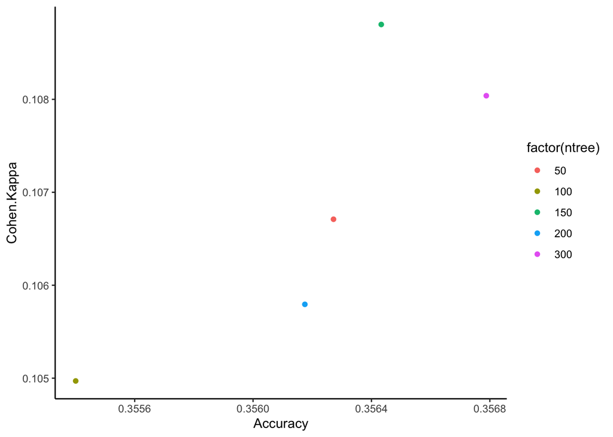

```r
g1 %>%
  ggplot(aes(x = Accuracy,
             y = Cohen.Kappa)) +
  geom_point(aes(color = factor(ntree))) +
  theme_classic()
```

These all seem to be relatively the same in terms of performance. So we’ll just look at ntree=150 to try out a variety of mtry values, and see their impact.

```r
performance(rf.prediction.150, ipums.test$federal.tax)
```

```
##          actual
## predicted  10%  12%  22%  24%  32%  35%  37%
##       10%  626  450  301   82    8   12    6
##       12%  921 1676 1251  522   86  171   27
##       22% 2474 3980 6871 4043  499  761  249
##       24%  477  762 1605 1875  338  586  330
##       32%    3    0    2    0    0    0    0
##       35%    1    0    0    1    0    0    0
##       37%    0    0    0    0    0    0    0
##    Accuracy Cohen.Kappa
## 1 0.3564331   0.1088053
##        recall precision
## 10% 0.4215488 0.1390493
## 12% 0.3601203 0.2440303
## 22% 0.3639879 0.6850449
## 24% 0.3139126 0.2874444
## 32% 0.0000000 0.0000000
## 35% 0.0000000 0.0000000
## 37%       NaN 0.0000000
```

Another improvement! Accuracy up to almost 36% and Kappa has passed 0.1 for the first time. Granted, this is still not particularly far from 0, but we are at least improving in the direction away from randomness.

```r
rf.2 <- randomForest(federal.tax ~ race +  deg.field + AGE + SEX,
                   data = ipums.train,
                   ntree =  150,
                   mtry = 2)
rf.3 <- randomForest(federal.tax ~ race +  deg.field + AGE + SEX,
                   data = ipums.train,
                   ntree =  150,
                   mtry = 3)
rf.4 <- randomForest(federal.tax ~ race + deg.field + AGE + SEX,
                   data = ipums.train,
                   ntree =  150,
                   mtry = 4)

save(rf.2,
     file = "rf.2.R")
save(rf.3,
     file = "rf.3.R")
save(rf.4,
     file = "rf.4.R")
```

```r
load('rf.2.R')
load('rf.3.R')
load('rf.4.R')

ipums.test$deg.field <- as.factor(ipums.test$deg.field)
ipums.test$race <- as.factor(ipums.test$race)
ipums.test$federal.tax <- as.factor(ipums.test$federal.tax)

rf.prediction.2 <- predict(rf.2,
                          ipums.test)
rf.prediction.3 <- predict(rf.3,
                          ipums.test)
rf.prediction.4 <- predict(rf.4,
                          ipums.test)

perf.2 <- performance(rf.prediction.2, ipums.test$federal.tax)
perf.3 <- performance(rf.prediction.3, ipums.test$federal.tax)
perf.4 <- performance(rf.prediction.4, ipums.test$federal.tax)

g2 <- rbind(perf.2[[2]] %>% mutate(mtry = 2),
            perf.3[[2]] %>% mutate(mtry = 3),
            perf.4[[2]] %>% mutate(mtry = 4))
```

Once again, plotting Accuracy vs Kappa.

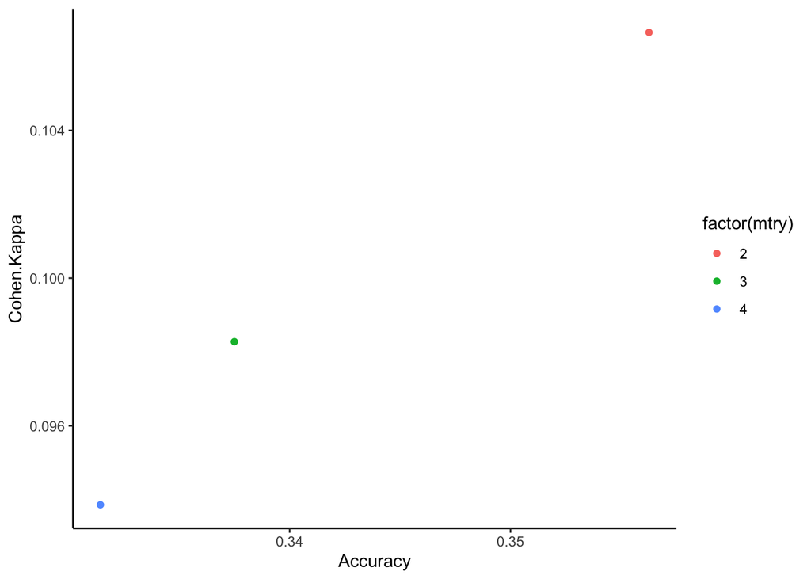

```r
g2 %>%
  ggplot(aes(x = Accuracy,
             y = Cohen.Kappa)) +
  geom_point(aes(color = factor(mtry))) +
  theme_classic()
```

mtry=2 appears to be our best bet here. However, something interesting is going on if we look at the confusion matrices.

```r
perf.2[[1]]
```

```
##          actual
## predicted  10%  12%  22%  24%  32%  35%  37%
##       10%  588  421  285   79    9   11    4
##       12%  942 1645 1215  503   77  160   26
##       22% 2522 4054 6993 4122  515  794  258
##       24%  449  748 1535 1817  330  565  324
##       32%    1    0    2    1    0    0    0
##       35%    0    0    0    1    0    0    0
##       37%    0    0    0    0    0    0    0
```

```r
perf.3[[1]]
```

```
##          actual
## predicted  10%  12%  22%  24%  32%  35%  37%
##       10%  632  521  406  152   17   23    7
##       12% 1069 1782 1651  786  107  221   40
##       22% 2026 3363 5784 3298  417  633  212
##       24%  748 1178 2152 2241  381  633  345
##       32%    9    3    8    7    1    1    0
##       35%   18   18   27   33    8   19    6
##       37%    0    3    2    6    0    0    2
```

```r
perf.4[[1]]
```

```
##          actual
## predicted  10%  12%  22%  24%  32%  35%  37%
##       10%  639  551  444  198   22   38   11
##       12% 1149 1886 1829  942  125  241   56
##       22% 1939 3232 5597 3177  421  630  229
##       24%  727 1144 2070 2106  342  576  294
##       32%   13   11   23   16    1    3    1
##       35%   32   34   53   70   17   37   14
##       37%    3   10   14   14    3    5    7
```

Although a lower mtry may be more accurate, we see that we are actually having increased success classifying those in higher tax brackets. This is a marked improvement from any previous model we’ve constructed. If our goal is not just accuracy, but rather improved performance across classes, then considering a higher number of variables seems to be important.

##### kNN

Let’s return to our roots and build a KNN model in the hopes that perhaps proximity will yield some decent results.

(Note: I write the predictions to a .csv to then read in later to once again save time.)

```r
knn.train <- scale(ipums.train_dummy)
knn.test <- scale(ipums.test_dummy)


knn.prediction.1  <-  knn(knn.train,
                          knn.test,
                          cl = ipums.train$federal.tax,
                          k = 1)
write.csv(knn.prediction.1,
          "knn.prediction.1.csv")
knn.prediction.2  <-  knn(knn.train,
                          knn.test,
                          cl = ipums.train$federal.tax,
                          k = 2)
write.csv(knn.prediction.2,
          "knn.prediction.2.csv")
knn.prediction.3  <-  knn(knn.train,
                          knn.test,
                          cl = ipums.train$federal.tax,
                          k = 3)
write.csv(knn.prediction.3,
          "knn.prediction.3.csv")
```

```r
knn.prediction.1 <- as.vector(fread("knn.prediction.1.csv")[-1,2])[[1]]
knn.prediction.2 <- as.vector(fread("knn.prediction.2.csv")[-1,2])[[1]]
knn.prediction.3 <- as.vector(fread("knn.prediction.3.csv")[-1,2])[[1]]

performance(knn.prediction.1, ipums.test$federal.tax)
```

```
##          actual
## predicted  10%  12%  22%  24%  32%  35%  37%
##       10%  681  638  477  163   17   36    7
##       12%  928 1633 1454  703   93  210   49
##       22% 1972 3336 5871 3287  424  673  229
##       24%  894 1233 2189 2339  391  602  321
##       32%    8    5   11   12    0    1    0
##       35%   17   22   24   16    5    7    4
##       37%    2    1    4    3    1    1    2
##   Accuracy Cohen.Kappa
## 1 0.339818   0.1019523
##         recall   precision
## 10% 0.33729569 0.151266104
## 12% 0.32209073 0.237769365
## 22% 0.37177052 0.585343968
## 24% 0.29351236 0.358577342
## 32% 0.00000000 0.000000000
## 35% 0.07368421 0.004575163
## 37% 0.14285714 0.003267974
```

```r
performance(knn.prediction.2, ipums.test$federal.tax)
```

```
##          actual
## predicted  10%  12%  22%  24%  32%  35%  37%
##       10%  665  630  464  159   18   34   10
##       12%  916 1622 1437  722  100  215   51
##       22% 1996 3363 5903 3295  420  680  232
##       24%  902 1222 2186 2314  386  589  315
##       32%    5    8   12   10    0    2    0
##       35%   16   22   24   17    6   10    4
##       37%    2    1    4    6    1    0    0
##    Accuracy Cohen.Kappa
## 1 0.3392051   0.1006134
##        recall   precision
## 10% 0.3358586 0.147712128
## 12% 0.3203634 0.236167734
## 22% 0.3715149 0.588534397
## 24% 0.2923932 0.354744749
## 32% 0.0000000 0.000000000
## 35% 0.1010101 0.006535948
## 37% 0.0000000 0.000000000
```

```r
performance(knn.prediction.3, ipums.test$federal.tax)
```

```
##          actual
## predicted  10%  12%  22%  24%  32%  35%  37%
##       10%  683  621  482  152   20   36   11
##       12%  928 1634 1446  706  101  213   52
##       22% 1972 3376 5864 3294  423  680  232
##       24%  898 1215 2202 2348  384  590  313
##       32%    4    4   12    7    0    0    0
##       35%   15   16   22   14    3   10    4
##       37%    2    2    2    2    0    1    0
##    Accuracy Cohen.Kappa
## 1 0.3400116   0.1017782
##        recall   precision
## 10% 0.3406484 0.151710351
## 12% 0.3216535 0.237914968
## 22% 0.3701787 0.584646062
## 24% 0.2953459 0.359957075
## 32% 0.0000000 0.000000000
## 35% 0.1190476 0.006535948
## 37% 0.0000000 0.000000000
```

##### GBM

Finally, we will construct a gradient boosted algorithm in order to hopefully deal with our underrepresented classes.

```r
gbm.model <- gbm(federal.tax ~ race + deg.field + AGE + SEX,
                  data = ipums.train,
                 n.trees = 1000,
                 distribution = "multinomial")

save(gbm.model,
     file = "gbm.model.R")
```

```r
load("gbm.model.R")

gbm.prediction <- gather(data.frame(predict.gbm(gbm.model,
        ipums.test,
        n.trees = 1000),
        obs = 1:nrow(ipums.test)),
        key = "federal.tax",
        value = "prob",
        -obs)

gbm.prediction$federal.tax <- as.factor(gbm.prediction$federal.tax)

levels(gbm.prediction$federal.tax) <- c("10%", "12%", "22%", "24%", "32%", "35%", "37%")

gbm.prediction <- gbm.prediction %>%
  group_by(obs) %>%
  filter(prob == max(prob))

performance(gbm.prediction$federal.tax, ipums.test$federal.tax)
```

```
##          actual
## predicted  10%  12%  22%  24%  32%  35%  37%
##       10%  179  249  363  225   27   53   18
##       12%  665 1001 1288  922  134  192   83
##       22% 2811 4278 6276 3941  538  957  376
##       24%  847 1340 2103 1435  232  328  135
##       32%    0    0    0    0    0    0    0
##       35%    0    0    0    0    0    0    0
##       37%    0    0    0    0    0    0    0
##    Accuracy Cohen.Kappa
## 1 0.2868435 0.009995685
##        recall  precision
## 10% 0.1606822 0.03976011
## 12% 0.2336056 0.14574840
## 22% 0.3272670 0.62572283
## 24% 0.2235202 0.21999080
## 32%       NaN 0.00000000
## 35%       NaN 0.00000000
## 37%       NaN 0.00000000
```

Unfortunately, we have returned back to essentially the same accuracy as linear regression and a terrible Kappa, once again ignoring the upper three tax brackets. It seems that GBM is not the answer.

### Conclusion

After all of these tests, I conclude that the randomForest is the best algorithm for this particular problem. I believe this is due to the fact that we have so many different factors and an uneven class distribution. Therefore, the randomForest algorithm with its bootstrapping and randomized variable choice allows for better predictions.

At the end of the day, the best performing algorithm managed to predict the correct class with about 36% accuracy and a Kappa of 0.11. These are certainly not ideal metrics, but there is still something to be gleaned from this exercise. Namely, our issues seem to stem from an uneven distribution of classes and computational limitations. If we had the computing capacity to consider industry, then perhaps our classifications would be more accurate. However, it’s not only issues that we glean. The succcess of kNN demonstrates a level of association between tax bracket and our predictor variables, but that success relies on specificity. The nuances of the problem require nuanced algorithms. Ultimately, based on our findings here, I feel that a random forest would most likely have the best success with a probelm similar to this. Perhaps, given more variables and greater computing power, we could achieve even greater results.